# Grappling with the “Hearing Events” scale

Last updated 2018-04-07

Here we look at the “hearing events” scale (Posey & Losch; Packet 3) in detail.

# Differences across fieldsites

## Mean scores by site

First, let’s look at scores for participants in each site:

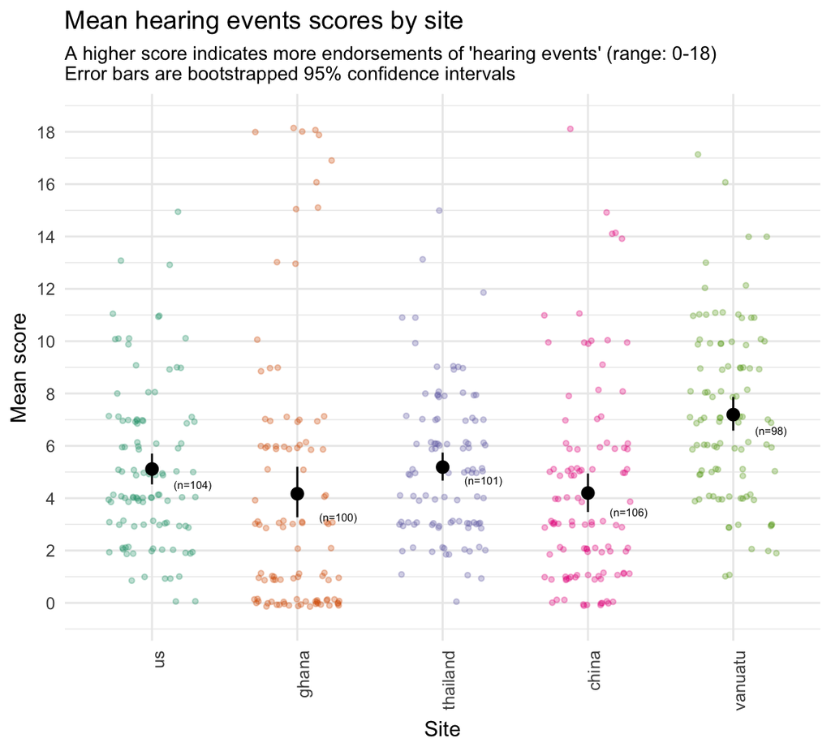

Note that this plot includes both average scores for each site (in black), and individual scores for all of the participants in that site (small, colorful points in the background, which are “jittered” around a little so that you can see them all).

A few things that jump out at me after looking very briefly at this:

- Surprisingly, the overall average for participants in Ghana was rather low. There were quite a few GH participants who scored a 0 on this - i.e., did not endorse any of these events. On the other hand, there’s a small cluster of participants who scored very high on this - i.e., endorsed nearly all of these events. These could be superficial response biases (e.g., if some participants just circled “no” or “yes” to everything), and/or they could indicative of different sub-groups of participants within this sample.
- The other distributions look pretty typical to me.
- If I were naively glancing at this plot, I would say “looks like all of these sites are basically same on this scale, except VT.”

Let’s look at these differences in more detail using the “raw data” for individual questions, rather than these subscale scores.

## Responses by question, by site

```
Column `question` joining character vector and factor, coercing into character vector
```

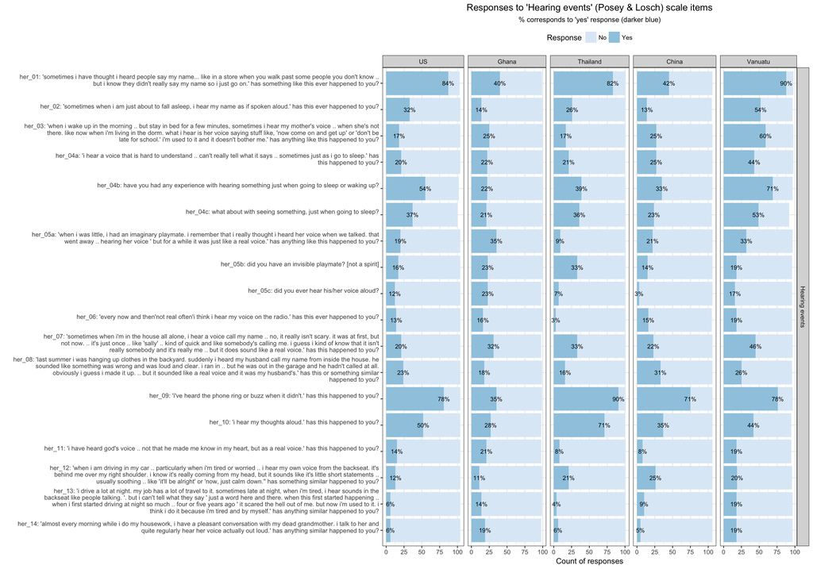

I have not looked at this in detail, but eager to hear others’ observations.

# Distribution of responses for individual participants, by site

Another thing we might be interested in is how individual participants responded: Were there people who said yes to everything, or no to everything? How do these distributions of responses differ across participants in different sites?

Let’s take a look:

```
Column `question` joining character vector and factor, coercing into character vector
```

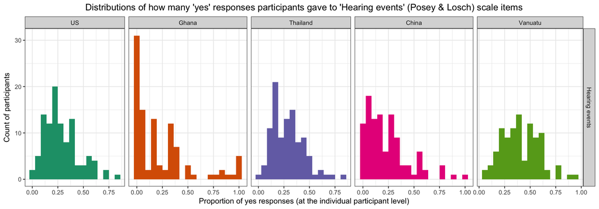

Again, the distribution in Ghana looks a little wacky; the other distributions look pretty typical to me. I haven’t thought about this deeply yet - looking forward to others’ thoughts!

Just for fun, here’s another way to look at the same data, overlaying the density distributions for each site on top of each other to see where they seem to be similar/different:

```
Column `question` joining character vector and factor, coercing into character vector
```

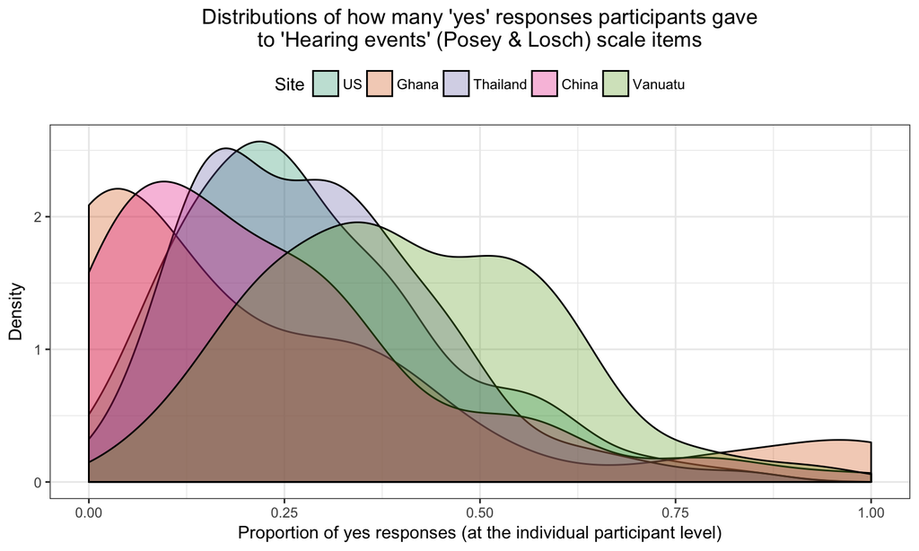